# Computer Practical 2: Plotting with ggplot2 (continued) and testing for normality

Dr Alice Risely a.risely@salford.ac.uk

# 1 Learning outcomes for today

What you will learn in this practical:

- Reminder of how to summarise and plot data
- Learn how to colour plots by a categorical variable
- Learn how to add trend lines and jittered points to plots
- Test numerical data for normality using the Shapiro-Wilk test
- You have a homework task at the end of the worksheet.

# 2 Practical 1 learning outcomes

In practical 1 you learned:

- How to use R as a calculator; e.g., **sqrt(9)**
- How to save *objects* to the working environment,;e.g., **a <- 100**
- How to install and load packages; **install.packages(“ggplot2”)** ; **library(ggplot2)**
- How to view data as a table in a separate tab; **View(pirates)**
- How to summarise numerical and categorical data to get the mean, minimum, and maximum; **summary(pirates$age)** and **table(pirates$sex)**
- How to change the data types to categorical data: **as.factor(pirates$id) ;** count data: **as.integer(pirates$parrots)**; and continuous data: **as.numeric(pirates$weight)**.
- How to make histograms, bar plots, scatter plots, and boxplots in ggplot2 and add axis labels and titles.

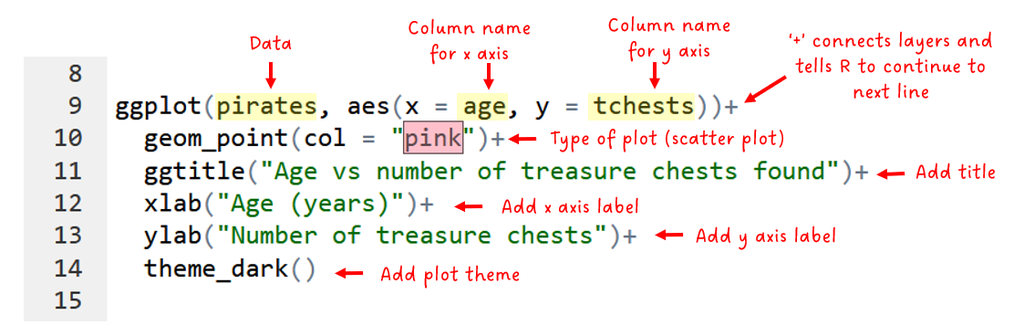

# 3 Preliminary tasks

1. I**f you have not completed practical 1, you need to do this first.** Please go back to Blackboard and click on the practical 1 word document and follow instructions.

2. If you are ready to start Practical 2, **DOWNLOAD the second practical worksheet** from Blackboard, do not just view it. To download it, click the “…” next to the file and click ‘Download original file’. **Save this file in an appropriately named folder on your OneDrive (e.g., “MODULE NAME/WEEK X”) so you can access it at home.**

3. **Navigate on your web browser to https://login.rstudio.cloud/.** Assuming you have already registered for practical 1, then sign in. If prompted, click “Posit Cloud”.

4. **You should already have an existing R studio project from the first practical called ‘R workshop’,** click on this to enter your saved workspace from practical 1.

5. **Start a new R script for this practical.** Once your project has loaded (it takes a few seconds), click ‘File’ then ‘New file’, then ‘R Script’.

7. **Press the Save button and save your script as “Practical_2.R”**. This will save all your code you write today. You should now have a screen that looks like this:

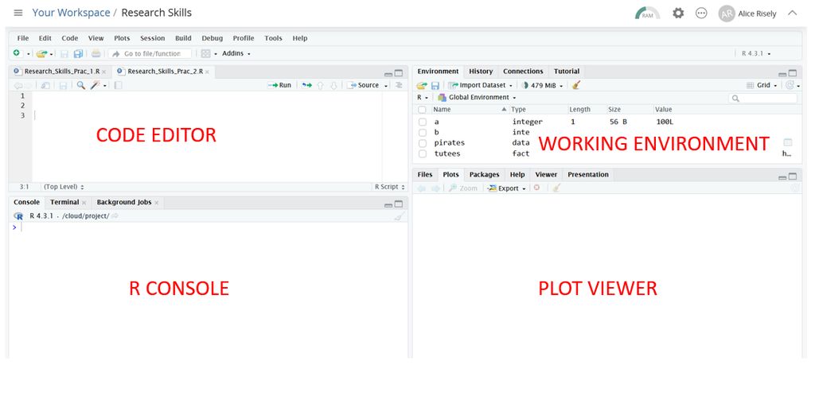

# 4 Recap: How to run code in R

- To run a line of code in R, put your mouse cursor on the line you want to run and press **Control and Enter** (this is the most common method). Alternatively, press the ‘Run’ button above the code editor.
- **Anything after a # key is NOT code**, it is comments/notes. R will ignore any writing after the # key. You do not need to copy out the comments into R.
- When you run the code, R will process your command and send it to the R console, where you will see both the code and the output.

# 5 Recap: Loading packages

The first thing you do when opening R is to load the packages you need. In this class, we will be using the packages ggplot2 for plotting, and yarrr for accessing the pirate data.

```r
library(ggplot2) # load the package ggplot2
library(yarrr) # load the package yarrr
```

# 6 Recap: Summarising data

First we will practice summarising and plotting data using the dataset *pirates*, which we explored in practical 1.

First, lets remind ourselves of this dataset by exploring it again.

```r
# data(pirates) # load the dataset 'pirates' into your environment if it is not tehre already. You should still have it from last week

head(pirates) # check the first six rows of the dataset
```

|  | id | sex | age | height | weight | headband | college | tattoos | tchests | parrots | favorite.pirate | sword.type | eyepatch | sword.time | beard.length | fav.pixar | grogg |
| --- | --- | --- | --- | --- | --- | --- | --- | --- | --- | --- | --- | --- | --- | --- | --- | --- | --- |
| 1 | 1 | male | 28 | 173.11 | 70.5 | yes | JSSFP | 9 | 0 | 0 | Jack Sparrow | cutlass | 1 | 0.58 | 16 | Monsters, Inc. | 11 |
| 2 | 2 | male | 31 | 209.25 | 105.6 | yes | JSSFP | 9 | 11 | 0 | Jack Sparrow | cutlass | 0 | 1.11 | 21 | WALL-E | 9 |
| 3 | 3 | male | 26 | 169.95 | 77.1 | yes | CCCC | 10 | 10 | 1 | Jack Sparrow | cutlass | 1 | 1.44 | 19 | Inside Out | 7 |
| 4 | 4 | female | 31 | 144.29 | 58.5 | no | JSSFP | 2 | 0 | 2 | Jack Sparrow | scimitar | 1 | 36.11 | 2 | Inside Out | 9 |
| 5 | 5 | female | 41 | 157.85 | 58.4 | yes | JSSFP | 9 | 6 | 4 | Hook | cutlass | 1 | 0.11 | 0 | Inside Out | 14 |
| 6 | 6 | male | 26 | 190.20 | 85.4 | yes | CCCC | 7 | 19 | 0 | Jack Sparrow | cutlass | 1 | 0.59 | 17 | Monsters University | 7 |

```r
names(pirates) # check names of the columns
```

```
##  [1] "id"              "sex"             "age"             "height"
##  [5] "weight"          "headband"        "college"         "tattoos"
##  [9] "tchests"         "parrots"         "favorite.pirate" "sword.type"
## [13] "eyepatch"        "sword.time"      "beard.length"    "fav.pixar"
## [17] "grogg"
```

```r
str(pirates) # look at the structure of the dataset and the data types of each column
```

```
## 'data.frame':    1000 obs. of  17 variables:
##  $ id             : int  1 2 3 4 5 6 7 8 9 10 ...
##  $ sex            : chr  "male" "male" "male" "female" ...
##  $ age            : num  28 31 26 31 41 26 31 31 28 30 ...
##  $ height         : num  173 209 170 144 158 ...
##  $ weight         : num  70.5 105.6 77.1 58.5 58.4 ...
##  $ headband       : chr  "yes" "yes" "yes" "no" ...
##  $ college        : chr  "JSSFP" "JSSFP" "CCCC" "JSSFP" ...
##  $ tattoos        : num  9 9 10 2 9 7 9 5 12 12 ...
##  $ tchests        : num  0 11 10 0 6 19 1 13 37 69 ...
##  $ parrots        : num  0 0 1 2 4 0 7 7 2 4 ...
##  $ favorite.pirate: chr  "Jack Sparrow" "Jack Sparrow" "Jack Sparrow" "Jack Sparrow" ...
##  $ sword.type     : chr  "cutlass" "cutlass" "cutlass" "scimitar" ...
##  $ eyepatch       : num  1 0 1 1 1 1 0 1 0 1 ...
##  $ sword.time     : num  0.58 1.11 1.44 36.11 0.11 ...
##  $ beard.length   : num  16 21 19 2 0 17 1 1 1 25 ...
##  $ fav.pixar      : chr  "Monsters, Inc." "WALL-E" "Inside Out" "Inside Out" ...
##  $ grogg          : num  11 9 7 9 14 7 9 12 16 9 ...
```

```r
View(pirates) # View the dataset in a different tab
```

Reminder:

- To summarise numerical data, you need the function **summary()**
- To summarise categorical data, you need the funtion **table()**

## 6.1 Exercise 1

What is the mean, minimum, and maximum of the number of treasure chests that pirates have found/stolen? Remember, number of treasure chests is count data, therefore it is numerical.

```r
summary(pirates$tchests)
```

```
##    Min. 1st Qu.  Median    Mean 3rd Qu.    Max.
##    0.00    6.00   15.00   22.69   30.00  147.00
```

```r
# mean= 22.7
# min = 0
# max = 147
```

What is the most popular pixar movie of pirates? Remember, favourite pixar movie is a categorical variable.

```r
table(pirates$fav.pixar)
```

```
##
##        A Bug's Life               Brave                Cars              Cars 2
##                  28                  21                  21                  14
##        Finding Nemo          Inside Out Monsters University      Monsters, Inc.
##                 162                 304                  94                  50
##         Ratatouille     The Incredibles           Toy Story         Toy Story 2
##                   3                  66                  16                  25
##         Toy Story 3                  Up              WALL-E
##                  13                 118                  65
```

```r
# ANSWER: Inside Out with 304 pirates saying this is their favourite Pizar movie
```

# 7 Recap: Basic plotting

We will continue with plotting in ggplot2 using the *pirates* dataset. In practical 1 you learned how to make basic plots, and also how to add axis labels, titles, and change the colours of your plots using the code highlighted in red below.

[figure not shown]

Practice basic plotting by completing the exercises below. Remember to use the cheat sheet (above or the paper handout) to help you.

## 7.1 Exercise 2

Make a histogram of pirate height. Add the title “Histogram of pirate height” and change the x axis label to “Height (cm)”.

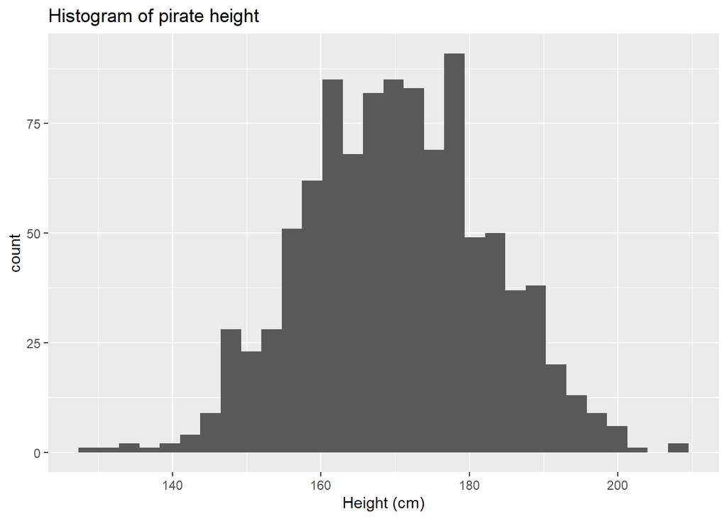

```r
ggplot(pirates, aes(x = height))+
  geom_histogram()+
  ggtitle("Histogram of pirate height")+
  xlab("Height (cm)")
```

## 7.2 Exercise 3

Make a bar plot showing the popularity of favourite pixar movies amongst pirates. Add the title “Favourite pixar movies of pirates” and change the x axis label to “Pixar movies”.

**HINT: Because the column names are so long, try putting favourite pixar movie on the y axis instead.** Normally the categorical variable should go on the x axis, but when variable names are long it is neater to put the categorical variable on the y axis.

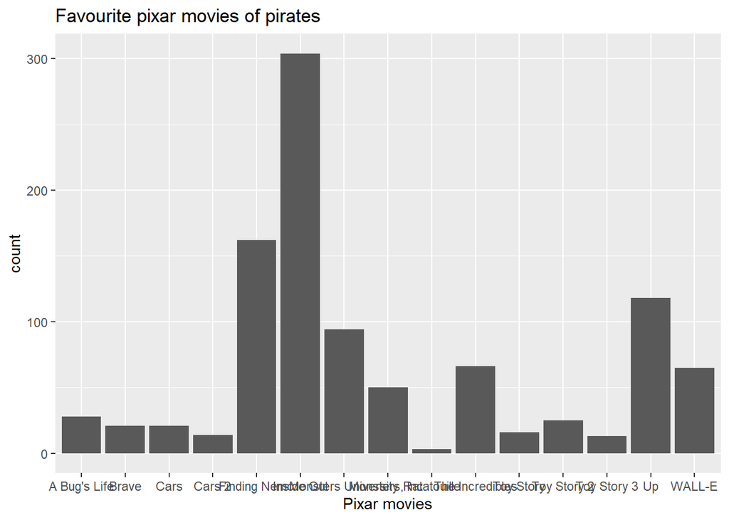

```r
# pixar movies on x axis
ggplot(pirates, aes(x = fav.pixar))+
  geom_bar()+
  ggtitle("Favourite pixar movies of pirates")+
  xlab("Pixar movies") # x axis label
```

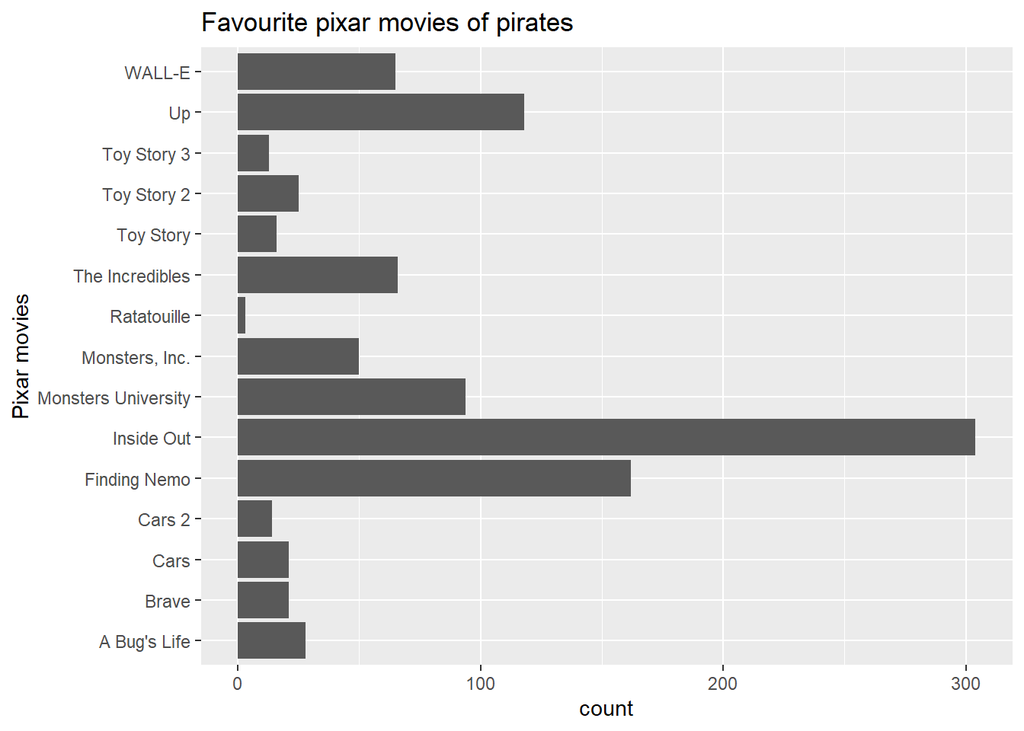

```r
# Pizar movie son y axis
ggplot(pirates, aes(y = fav.pixar))+
  geom_bar()+
  ggtitle("Favourite pixar movies of pirates")+
  ylab("Pixar movies") # y axis label
```

## 7.3 Exercise 4

Make a scatter plot showing the relationship between weight and height in pirates. Add a title and sensible axis labels (with units).

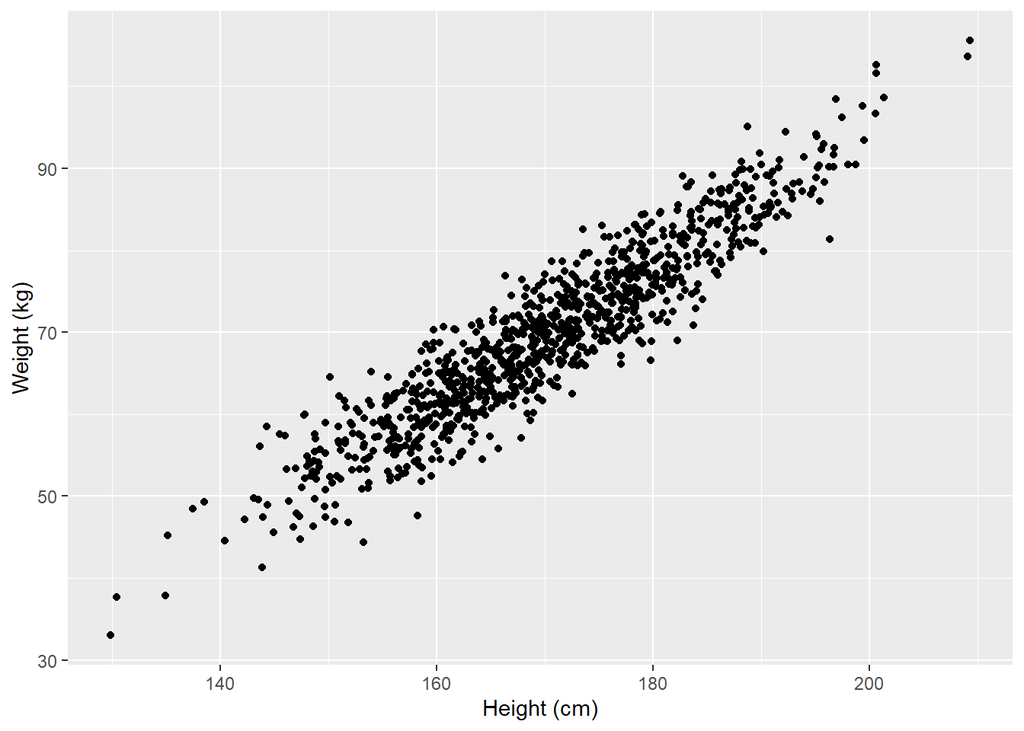

```r
ggplot(pirates, aes(x = height, y  = weight))+
  geom_point()+
  xlab("Height (cm)")+
  ylab("Weight (kg)")
```

## 7.4 Exercise 5

Make a boxplot to see whether the age of pirates differs by what college they went to. Add a title and sensible axis labels (with units).

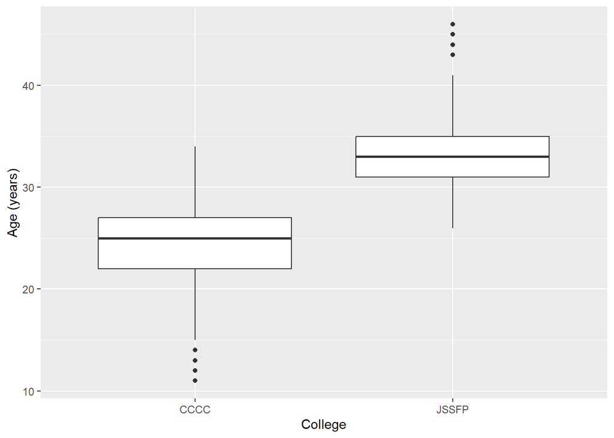

```r
ggplot(pirates, aes(x = college, y = age))+
  geom_boxplot()+
  xlab("College")+
  ylab("Age (years)")
```

# 8 Adding a trend line to a scatterplot

Sometimes when you have made a scatter plot it is useful to visualise a trendline. To do this, you add the layer: **geom_smooth():**

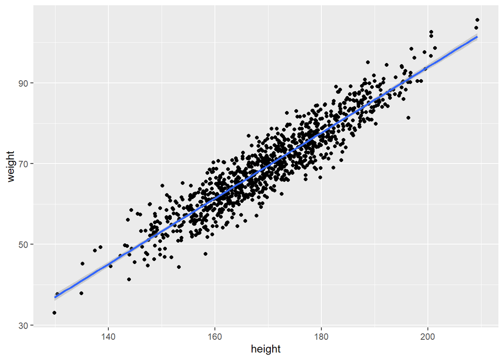

```r
ggplot(pirates, aes(x = height, y  = weight))+
  geom_point()+                                  # scatter plot
  geom_smooth(method = "lm")                     # trend line
```

**NOTE: The *method = “lm”* argument ensures the line is straight - not wobbly.** In most cases, you want a linear trend line, not a wobbly one unless you suspect a non-linear relationship.

# 9 Overlaying jittered points to a boxplot

Sometimes when you have made a boxplot, it is useful to overlay the raw datapoints over the boxplot so you can see the variation in the data. To do this, you can use the layer **geom_jitter().** Below is a boxplot of age distribution of pirates that went to different schools, overlayed by the raw data points:

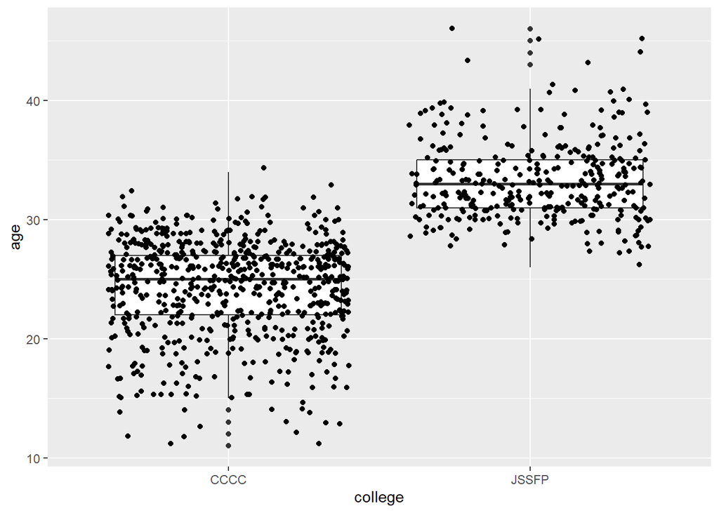

```r
ggplot(pirates, aes(x = college, y = age))+
  geom_boxplot()+                          # boxplot
  geom_jitter()                            # jittered points
```

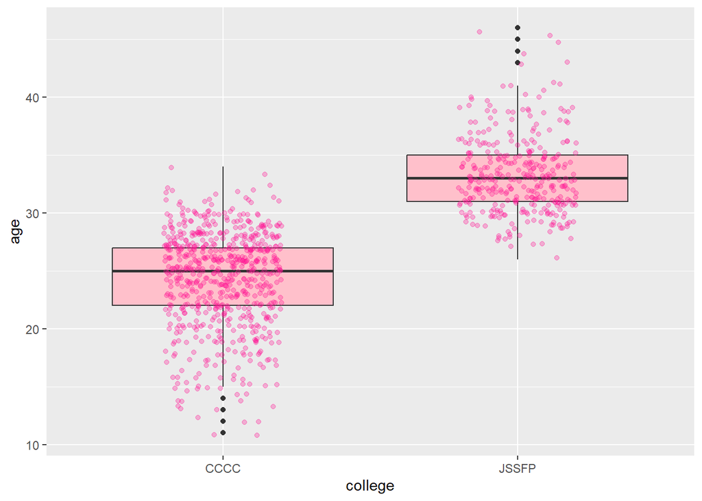

```r
#make points a bit narrower

ggplot(pirates, aes(x = college, y = age))+
  geom_boxplot(fill = "pink")+
  geom_jitter(width = 0.2, col = "deeppink", alpha = 0.3)  # make points a bit narrower, colour them pink, make a bit transparent (with alpha)
```

# 10 Colouring plots by a categorical variable

So far, we have used the arguments *col = “yellow”* or *fill = “pink”* to change the colour or fill of our plots elements. **However, sometimes it is useful to colour your data by a categorical variable, rather than just plot a single colour.**

For example, lets make a boxplot that compares beard length across pirate sex. Compare the colours of these two plots:

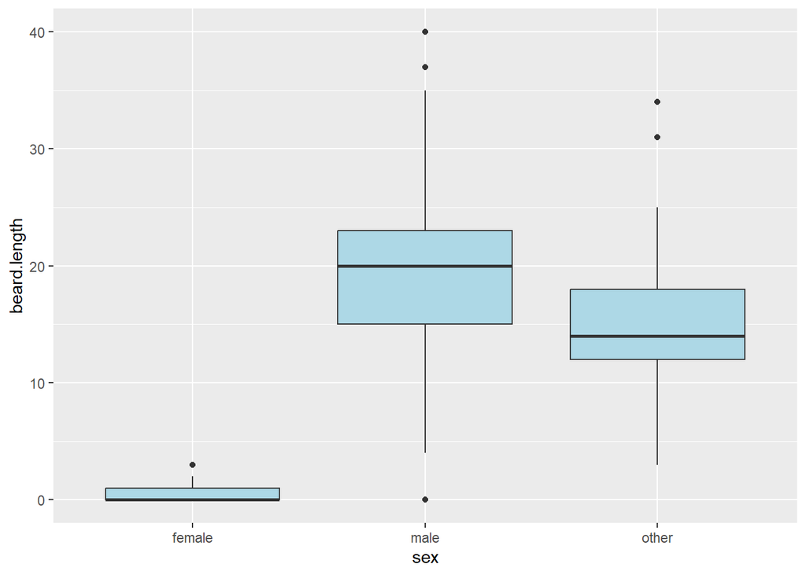

```r
# colour the boxes light blue and the points red

ggplot(pirates, aes(x = sex, y = beard.length))+
  geom_boxplot(fill = "lightblue")
```

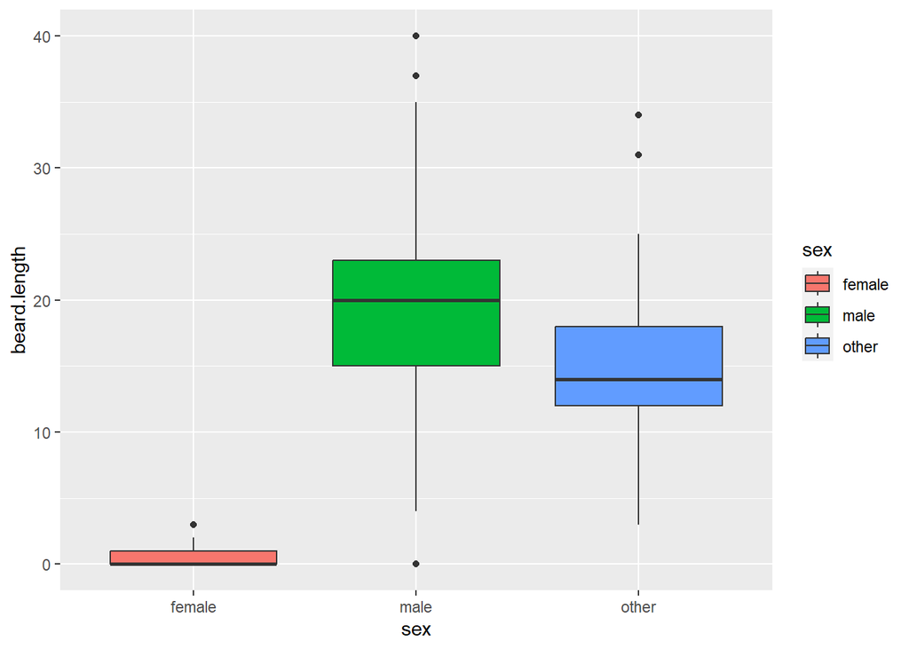

```r
# colour the boxes by sex (note = you dont have to specify any colours! It does that automatically)

ggplot(pirates, aes(x = sex, y = beard.length,

                    fill = sex))+ # <-- NOTICE THIS BIT
  geom_boxplot()
```

In the first plot, the fill of all the boxes is light blue. However, in the second plot, you have told ggplot to colour the boxes by pirate sex by adding ‘fill = sex’ in your mapping (aes) function in the first line.

ggplot(pirates, aes(x = sex, y = beard.length, *fill = sex*))+ geom_boxplot()

**Notice it will automatically provided a *legend* on the right.**

**Notice that because you are referring to the column ‘sex’ in your pirates dataset, the instruction *fill = sex* MUST be inside the *aes()* brackets. This is because ggplot will only know you are referring to a column name if it is inside the *aes()* brackets.**

Now lets practice with a scatter plot:

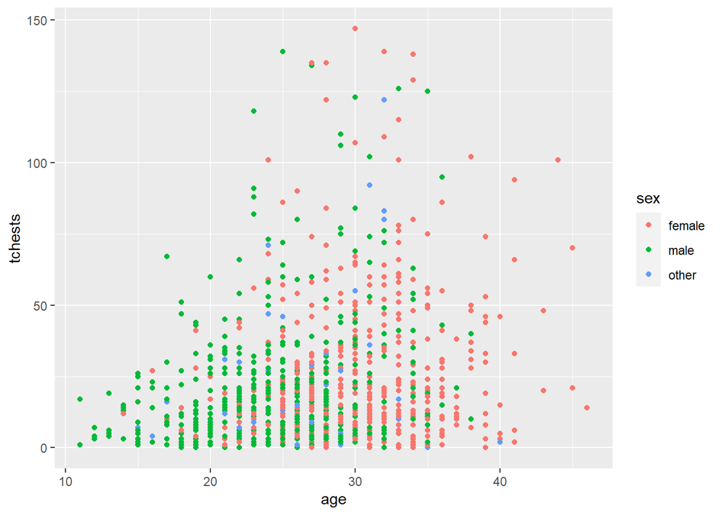

```r
ggplot(pirates, aes(x = age, y = tchests,
                    col = sex))+ # <-- NOTICE THIS BIT
  geom_point()
```

Note: For colouring your plots, use the argument *col* for scatter plots and *fill* for all other plot types:

**col = sex** : scatter plots

**fill = sex** : histograms, bar plots, and boxplots

## 10.1 Exercise 6

Make a barplot showing how many pirates wear headbands compared to those who don’t, and colour the plot by headband. Note, for barplot, you use the argument *fill*, not *col*.

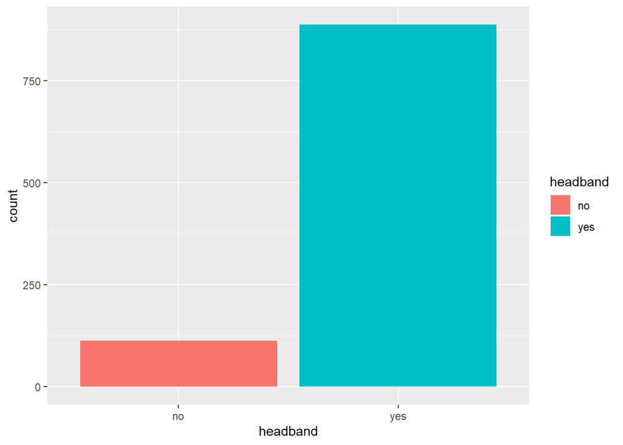

```r
ggplot(pirates, aes(x = headband, fill = headband))+
  geom_bar()
```

## 10.2 Exercise 7

Make a scatterplot of age against height, and colour the points by sex. Add a trendline and colour this by sex too (i.e, there should be three trend lines in your plot, one per sex).

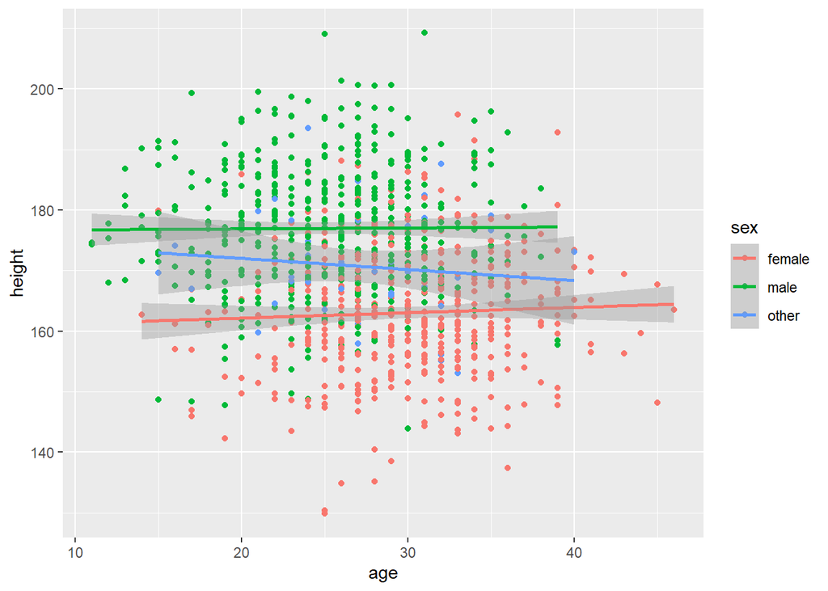

```r
ggplot(pirates, aes(x = age, y = height, col = sex))+
  geom_point()+
  geom_smooth(method = "lm")
```

Note: you could also do the same with this code:

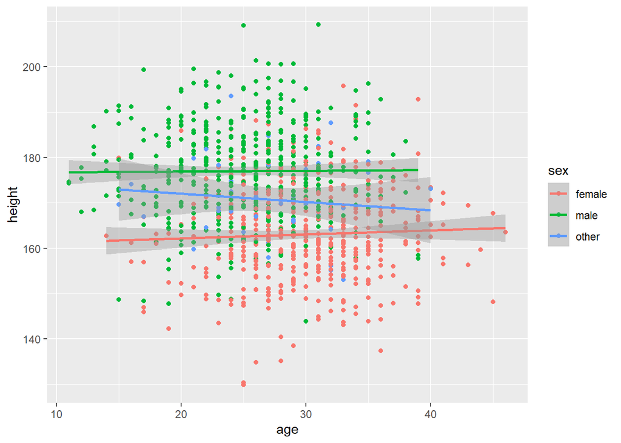

```r
ggplot(pirates, aes(x = age, y = height))+
  geom_point(aes(col = sex))+
  geom_smooth(method = "lm", aes(col = sex))
```

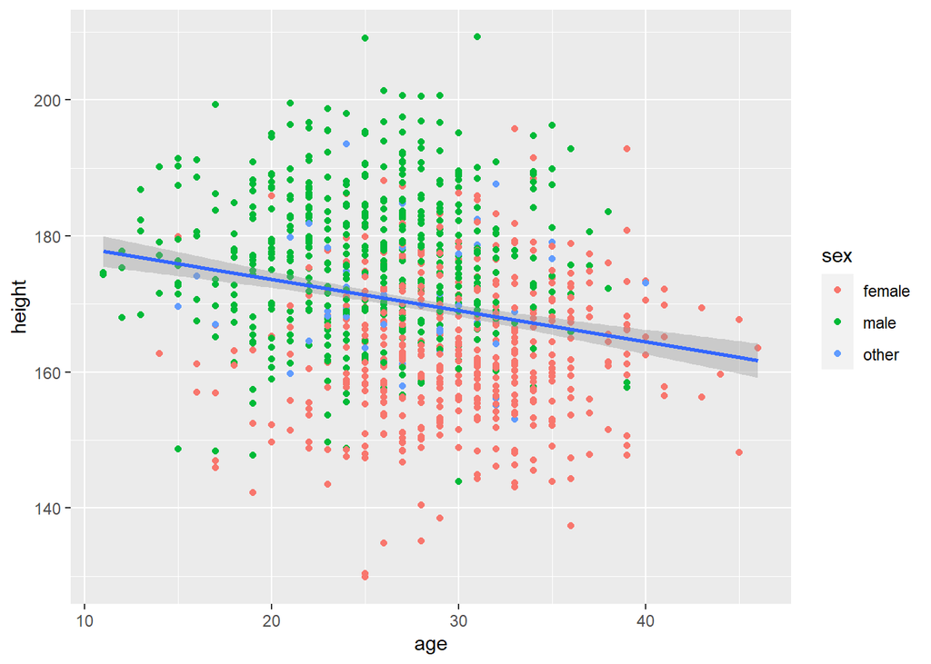

```r
# Or, if you ONLY want the points coloured by sex, but NOT the trend line:

ggplot(pirates, aes(x = age, y = height))+
  geom_point(aes(col = sex))+
  geom_smooth(method = "lm")
```

# 11 Manually assigning colours

Unfortunately, the automatic colours chosen by ggplot2 when colouring by a categorical variable are rather ugly in my opinion. For those who like creating pretty plots, you can manually tell ggplot what colours you want it to use when colouring by a categorical variable, by using the layer **scale_fill_manual()**, or *scale_colour_manual()*, depending on if you have used *col* or *fill* to specify colour. However, this is not essential.

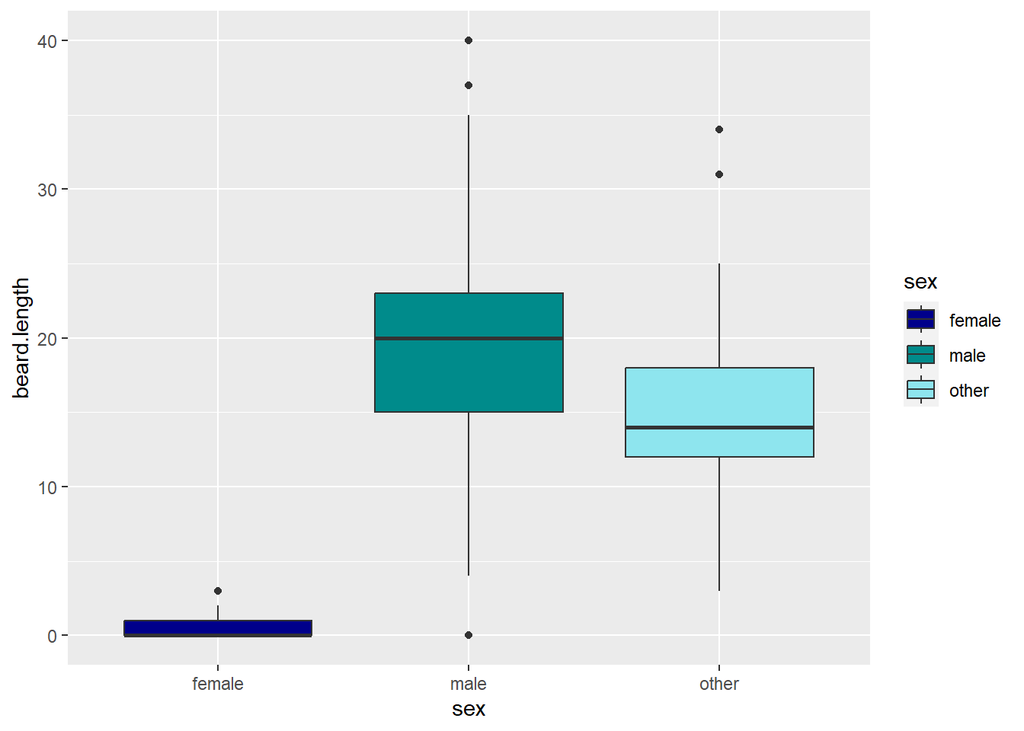

```r
# Boxolot with colours chosen manually:

ggplot(pirates, aes( x = sex, y = beard.length, fill = sex))+
  geom_boxplot()+
  scale_fill_manual(values = c("darkblue", "darkcyan", "cadetblue2"))
```

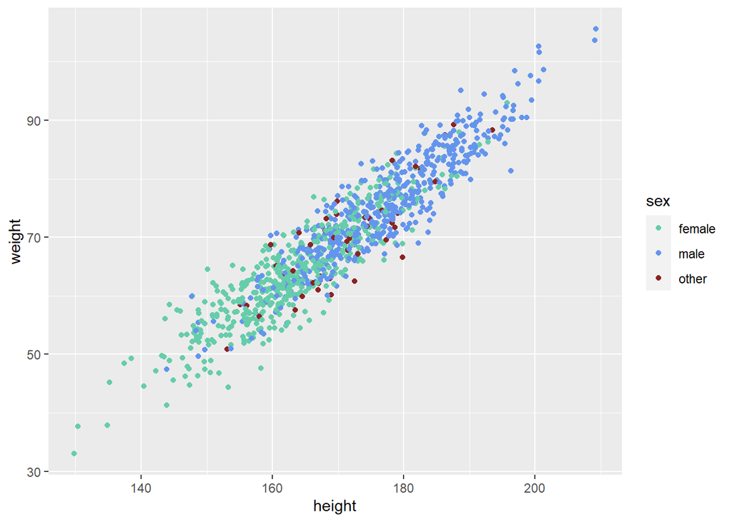

```r
# Scatterplot with colours chosen manually:

ggplot(pirates, aes( x = height, y = weight, col = sex))+
  geom_point()+
  scale_colour_manual(values = c("aquamarine3", "cornflowerblue", "brown4"))
```

Here are the names of some colours in R, and you can find more here: https://bookdown.org/hneth/ds4psy/D-3-apx-colors-basics.html

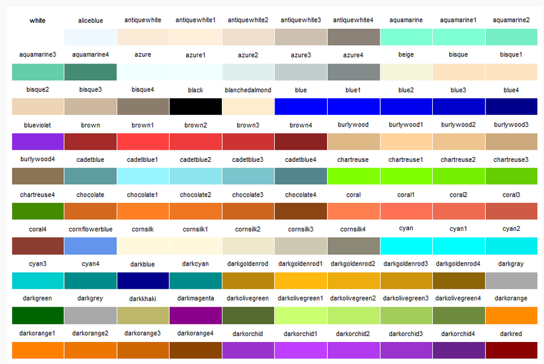

# 12 Distribution curves

Think back to the part in last weeks lecture about common distribution curves (which can be gauged from histograms):

[figure not shown]

The most important distribution curve is the NORMAL DISTRIBUTION (or bell-shaped curve). To be able to choose a statistical test, you need to know if your numerical data is normal or not.

**To do this, you need to 1) plot a histogram of your numerical data, and 2) perform a Shapiro-Wilk test of normality**.

If the p value from your test is above 0.05, you can be confident that your data IS normally distributed. Remember this slide from the lecture:

[figure not shown]

Lets now test some the numerical variables in the *pirates* dataset for normality. First, lets make two histograms:

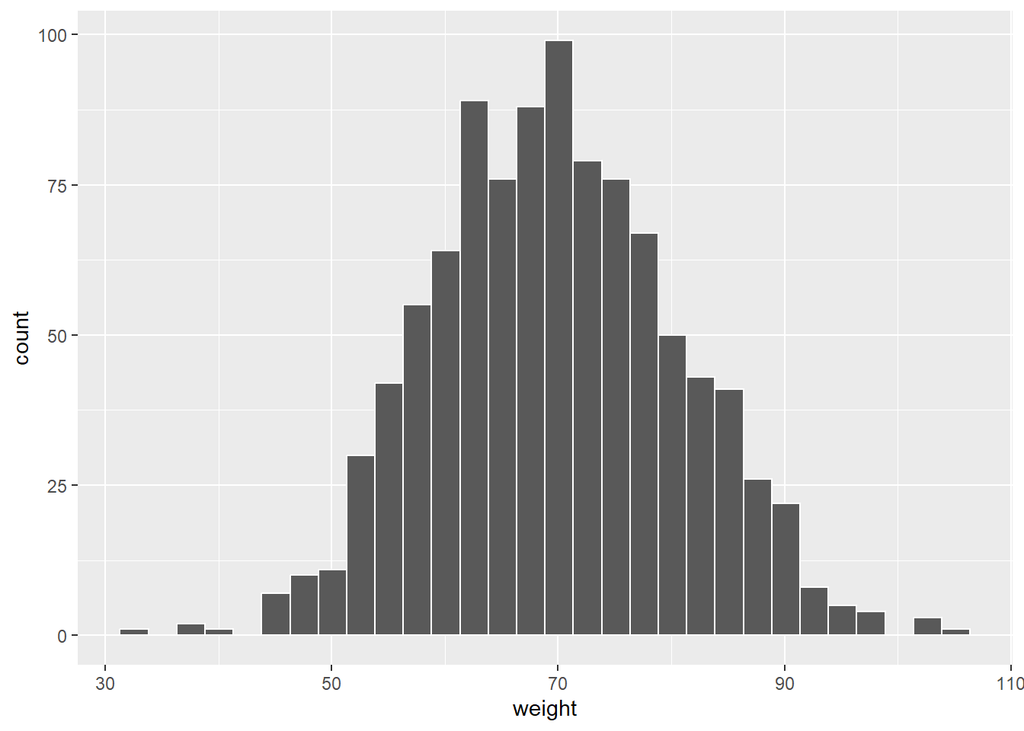

```r
# histogram of pirate weight

ggplot(pirates, aes(x = weight))+
  geom_histogram(col = "white")
```

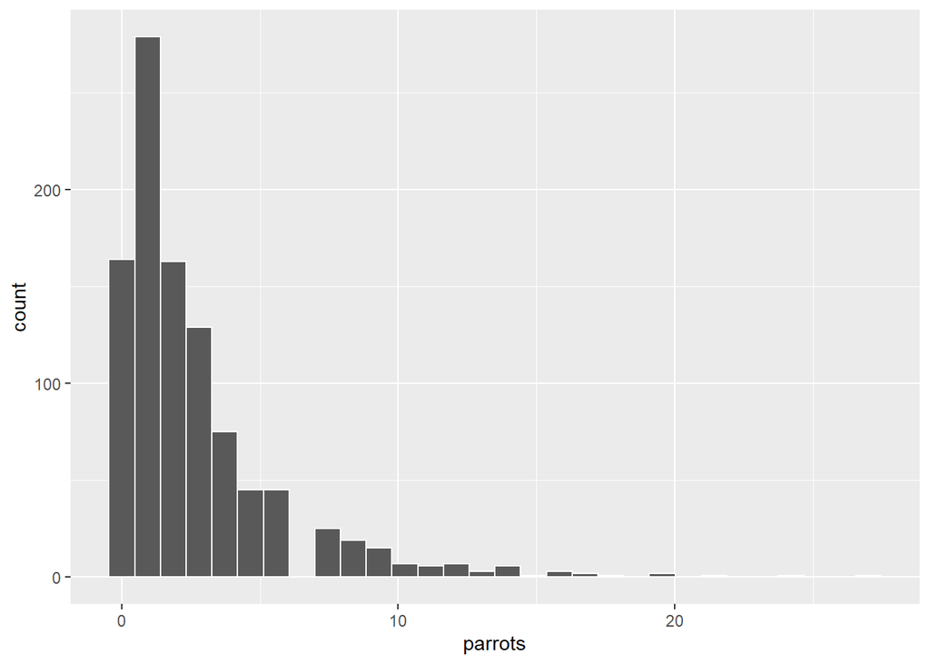

```r
# histogran of number of parrots owned by pirates

ggplot(pirates, aes(x = parrots))+
  geom_histogram(col = "white")
```